# Reddit Data Analysis

Originally written by Bon Woo Koo & Subhro Guhathakurta; modified by Uijeong Hwang

2023-10-31

```r
# Package names
packages <- c("RedditExtractoR", "anytime", "magrittr", "ggplot2", "dplyr", "tidytext", "tidyverse", "igraph", "ggraph", "tidyr", "wordcloud2", "textdata", "sf", "tmap")

# Install packages not yet installed
installed_packages <- packages %in% rownames(installed.packages())
if (any(installed_packages == FALSE)) {
install.packages(packages[!installed_packages])
}

# Load packages
invisible(lapply(packages, library, character.only = TRUE))
```

**DISCLAIMER**: Due to the uncensored nature of online communities, you may encounter posts with images that are not suited for work / school. You may see some that are controversial as well. This is part of the urban analytics. That said, I hope no one gets offended or upset by anything we may encounter.

# 1. Let’s get some Reddit data

We will use `RedditExtractoR` package to collect Reddit data. `RedditExtractoR::find_thread_urls()` function lets you search for threads based on a name of subreddit, a keyword, or a combination of both. The function takes four arguments:

- `keywords`
- `subreddit` (optional)
- `sort_by`: “top” (default), “relevance”, “comments”, “new”, “hot”, “rising”
  - If you are searching by keywords: relevance, comments, new, hot, top
  - Otherwise: hot, new, top, rising
- `period`: “month” (default), “hour”, “day”, “week”, “year”, “all”

Although the package description does not explicitly says so, it appears that the `find_thread_urls()` function retrieves maximum 1,000 threads when searched by a subreddit, and maximum 250 threads when searched either by a keyword, or by a combination of a subreddit and a keyword.

## 1-1: Downloading Reddit threads

Let’s first find threads using a keyword ‘flu shot’. Check what the output object looks like.

```r
# using keyword
threads_1 <- find_thread_urls(keywords= "flu shot",
                              sort_by = 'relevance',
                              period = 'year')
```

```
## parsing URLs on page 1...
## parsing URLs on page 2...
## parsing URLs on page 3...
```

```r
colnames(threads_1)
```

```
## [1] "date_utc"  "timestamp" "title"     "text"      "subreddit" "comments"
## [7] "url"
```

```r
head(threads_1)
```

```
##     date_utc  timestamp
## 1 2023-09-04 1693794424
## 2 2023-06-20 1687261506
## 3 2023-09-19 1695149247
## 4 2023-05-18 1684392081
## 5 2023-09-16 1694886059
## 6 2023-09-27 1695812222
##                                                      title
## 1                                 How do I get a flu shot?
## 2      Can I get a flu shot the week after I have the flu?
## 3                      Pros And Cons Of Getting A Flu Shot
## 4                                       fucking flu shots.
## 5 Where to direct uninsured people for low cost flu shots?
## 6                   Why does my arm hurt after a flu shot?
##                                                                                                                                                                                                                                                                                                          …
```

[output cut: 20 more lines]

We can search for a list of subreddits related to the keyword of interest.

```r
# search for subreddits
subreddit_list <- RedditExtractoR::find_subreddits('flu shot')
```

```
## parsing URLs on page 1...
```

```r
subreddit_list[1:25,c('subreddit','title','subscribers')] %>% knitr::kable()
```

|  | subreddit | title | subscribers |
| --- | --- | --- | --- |
| 1 | flushot | Flu Shot | 17 |
| 2 | Health | Health | 1716938 |
| 3 | conspiracy | conspiracy | 2010512 |
| 4 | MurderedByAntivaxx | Murdered By Antivaxx | 2847 |
| 5 | recreationalvaccines | recreationalvaccines | 214 |
| 6 | vaxxhappened | Robert F KennedyJr is just another liar | 361559 |
| 7 | pharmacy | Pharmacy | 150017 |
| 8 | disenchantment | Disenchantment | 79147 |
| 9 | UofArizona | University of Arizona | 13130 |
| 10 | BabyBumps | Baby Bumps | 373193 |
| 11 | insanepeoplefacebook | Insane People on Social Media | 2108960 |
| 13 | CVS | CVS | 48451 |
| 14 | AskReddit | Ask Reddit… | 43222485 |
| 15 | skeptic | skeptic | 176380 |
| 16 | askscience | AskScience: Got Questions? Get Answers. | 24428837 |
| 17 | DebateVaccines | Debate Vaccines | 21922 |
| 18 | news | News | 26796159 |
| 19 | nursing | Nursing for nurses and by nurses for the care of all. | 488420 |
| 20 | CoronavirusCirclejerk | We are all going to die. | 55316 |
| 21 | TalesFromThePharmacy | Technicians, Pharmacists and other related professions | 164998 |
| 22 | teenagers | r/teenagers | 2963655 |
| 23 | funny | funny | 53060820 |
| 24 | Coronavirus | Novel Coronavirus (COVID-19) | 2321370 |
| 25 | facepalm | now double verified | 7727784 |
| 26 | VACCINES | Discussion of Vaccines | 6979 |

We can also check the number of threads found by the keyword per subreddit.

```r
threads_1$subreddit %>% table() %>% sort(decreasing = T) %>% head(10)
```

```
## .
##                   CVS ScienceBasedParenting              pregnant
##                     6                     6                     5
##       WalgreensStores     NoStupidQuestions              pharmacy
##                     5                     4                     4
##               alberta               AskDocs                canada
##                     3                     3                     3
##            conspiracy
##                     3
```

The subreddit ‘pharmacy’ seems interesting. Now let’s search by the subreddit.

```r
# using subreddit
threads_2 <- find_thread_urls(subreddit = 'pharmacy',
                              sort_by = 'top',
                              period = 'year')
```

```
## parsing URLs on page 1...
## parsing URLs on page 2...
## parsing URLs on page 3...
## parsing URLs on page 4...
## parsing URLs on page 5...
## parsing URLs on page 6...
## parsing URLs on page 7...
## parsing URLs on page 8...
## parsing URLs on page 9...
## parsing URLs on page 10...
```

Let’s search by both the keyword ‘flu shot’ and the subreddit ‘pharmacy’.

```r
# using both subreddit and keyword
threads_3 <- find_thread_urls(keywords="flu shot",
                              subreddit = 'pharmacy',
                              sort_by = 'relevance',
                              period = 'year')
```

```
## parsing URLs on page 1...
```

## 1-2: Downloading comments and additional information

The `find_thread_urls()` function provides title and text of threads, but not comments of each thread; it only shows the number of comments. `get_thread_content` function searches comments using URLs provided by the `find_thread_urls()` function. One caveat is that it takes really long. In the following example, therefore, we only `get_thread_content` for the first 10 threads.

```r
# get individual comments
threads_2_content <- get_thread_content(threads_2$url[1:10])
names(threads_2_content)
```

```
## [1] "threads"  "comments"
```

> `downvotes` column appears to be always zero; but fortunately, `up_ratio` column provides an insight on how positively or negatively users reacted to that thread.

```r
# check upvotes and downvotes
print(threads_2_content$threads[,c('upvotes','downvotes','up_ratio')])
```

```
##    upvotes downvotes up_ratio
## 1       64         0     0.87
## 2       64         0     0.94
## 3       68         0     0.87
## 4       65         0     0.93
## 5       64         0     0.94
## 6       65         0     0.90
## 7       66         0     0.96
## 8       62         0     0.92
## 9       64         0     0.87
## 10      61         0     0.95
```

The `comments` data frame provides information on individual comments.

```r
head(threads_2_content$comments, 5)
```

```
##                                                                                     url
## 1 https://www.reddit.com/r/pharmacy/comments/10ceies/opioids_are_out_stimulants_are_in/
## 2 https://www.reddit.com/r/pharmacy/comments/10ceies/opioids_are_out_stimulants_are_in/
## 3 https://www.reddit.com/r/pharmacy/comments/10ceies/opioids_are_out_stimulants_are_in/
## 4 https://www.reddit.com/r/pharmacy/comments/10ceies/opioids_are_out_stimulants_are_in/
## 5 https://www.reddit.com/r/pharmacy/comments/10ceies/opioids_are_out_stimulants_are_in/
##          author       date  timestamp score upvotes downvotes golds
## 1  firemylasers 2023-01-16 1673851045    19      19         0     0
## 2     [deleted] 2023-01-16 1673853340     9       9         0     0
## 3 Aurora_Lucens 2023-01-15 1673795908    53      53         0     0
## 4  Berchanhimez 2023-01-15 1673819517    -7      -7         0     0
## 5     Ok_Ad5315 2023-01-16 1673875158     8       8         0     0
##                                                                                                                                                                                                                                                                                                          …
## 1 https://www.federalregister.gov/documents/2022/12/02/2022-26351/established-aggregate-production-quotas-for-schedule-i-and-ii-controlled-substances-and-assessment\n\n&gt;Issue (Adderall Shortages):\n\n&gt;DEA received comments expressing general concerns regarding the ongoing shortages experien…
## 2                                                                                                                                                                                                                                                                                                        …
## 3                                                                                                                                                                                                                                                                                                        …
## 4                                                                                                                                                                                                                                                                                                        …
## 5                                                                                                                                                                                                                                                                                                        …
##   comment_id
## 1          1
## 2        1_1
## 3          2
## 4        2_1
## 5      2_1_1
```

## 1-3: Analyses on posting date/time

Using date and timestamp, we can analyze when is popular month, day, or time for posting on Reddit. First, let’s look at the number of threads by week for the last 12 months.

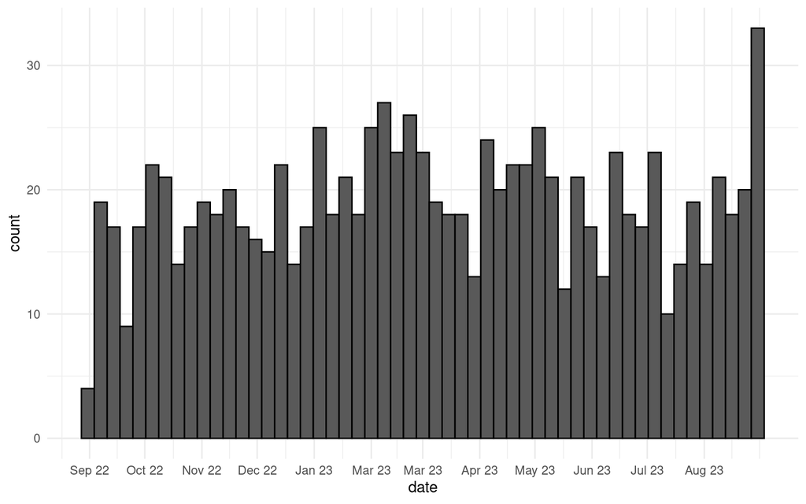

```r
# create new column: date
threads_2 %<>%
  mutate(date = as.POSIXct(date_utc)) %>%
  filter(!is.na(date))

# number of threads by week
threads_2 %>%
  ggplot(aes(x = date)) +
  geom_histogram(color="black", position = 'stack', binwidth = 60*60*24*7) +
  scale_x_datetime(date_labels = "%b %y",
                   breaks = seq(min(threads_2$date, na.rm = T),
                                max(threads_2$date, na.rm = T),
                                by = "1 month")) +
  theme_minimal()
```

Do people post more on weekends or weekdays?

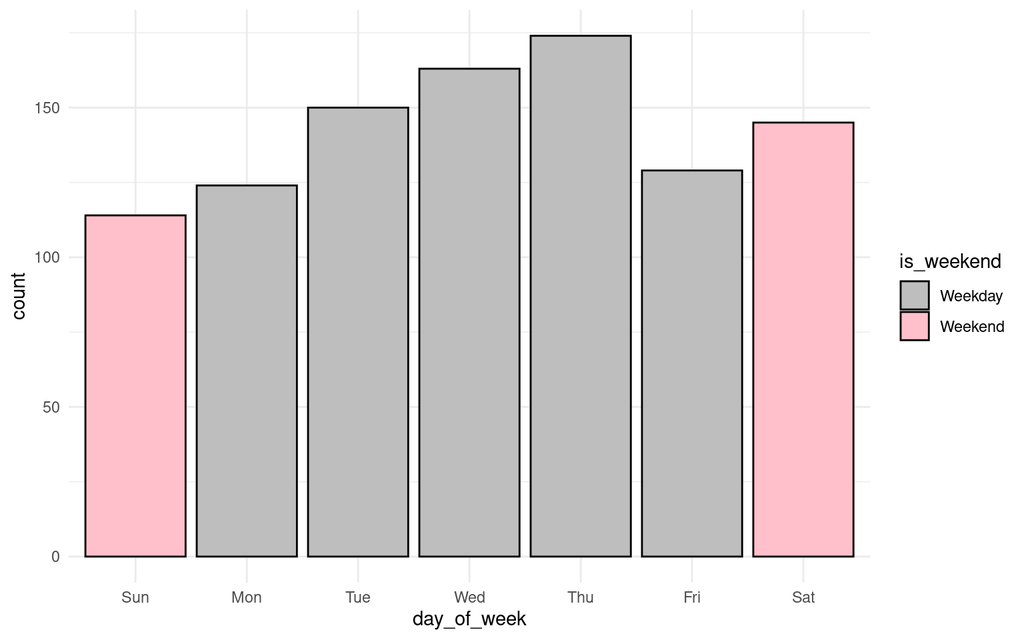

```r
# create new columns: day_of_week, is_weekend
threads_2 %<>%
  mutate(day_of_week = wday(date, label = TRUE)) %>%
  mutate(is_weekend = ifelse(day_of_week %in% c("Sat", "Sun"), "Weekend", "Weekday"))

# number of threads by time of day
threads_2 %>%
  ggplot(aes(x = day_of_week, fill = is_weekend)) +
  geom_bar(color = 'black') +
  scale_fill_manual(values = c("Weekday" = "gray", "Weekend" = "pink")) +
  theme_minimal()
```

How about time of day? We will get the time of day using the `timestamp` column. See what `anytime` package does below.

```r
print(threads_2$timestamp[1])
```

```
## [1] 1673770695
```

```r
print(threads_2$timestamp[1] %>% anytime(tz = anytime:::getTZ()))
```

```
## [1] "2023-01-15 08:18:15 GMT"
```

```r
threads_2 %<>%
  mutate(time = timestamp %>%
           anytime(tz = anytime:::getTZ()) %>%
           str_split('-| |:') %>%
           sapply(function(x) as.numeric(x[4])))
```

Let’s visualize the number of threads by time of day using the `time` column we made from `timestamp`.

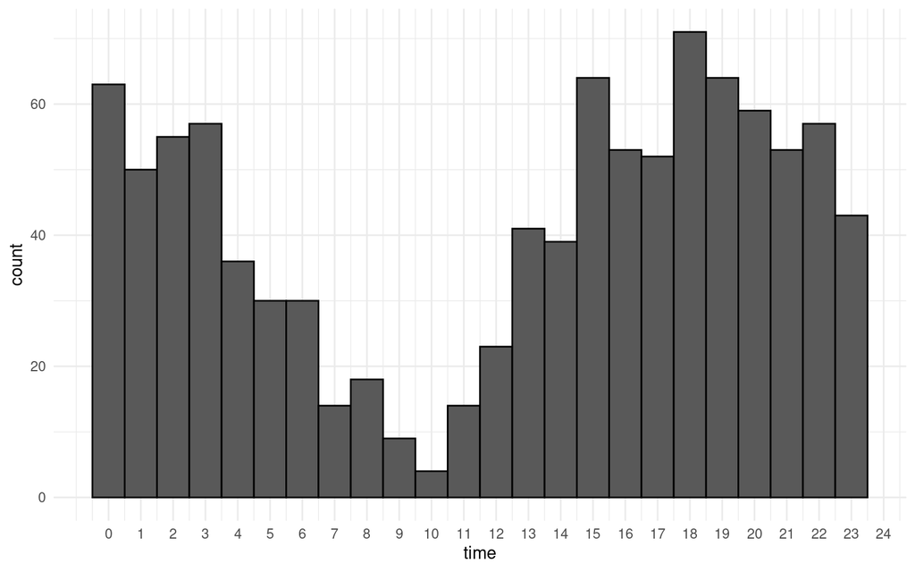

```r
# number of threads by time of day
threads_2 %>%
  ggplot(aes(x = time)) +
  geom_histogram(bins = 24, color = 'black') +
  scale_x_continuous(breaks = seq(0, 24, by=1)) +
  theme_minimal()
```

# 2. Tokenization and stop words

## 2-1: Tokenization

Tokenization is the fundamental starting point in any NLP pipeline. “Tokenization is a way of separating a piece of text into smaller units called tokens. Here, tokens can be either words, characters, or subwords. Hence, tokenization can be broadly classified into 3 types – word, character, and subword (n-gram characters) tokenization” (direct quotes from [here](https://www.analyticsvidhya.com/blog/2020/05/what-is-tokenization-nlp/)).

As an example, consider “How are you?” Most common way of tokenization is to break at space, resulting in how-are-you. You can also do character token, e.g., h-e-l-l-o, or sub-word, e.g., smart-er.

Then, if you code each token with a number, which allows us to represent textual data into numeric. For example, if we code h: 1, e: 2, l: 3, o:4, hello would be represented as 12334. The word heel, then can be written as 1223, and so on. You can already see the similarity between the two words, 12334 and 1223. This tokenization will be useful later when we do more sophisticated works.

To learn more, I found [this video](https://www.youtube.com/watch?v=fNxaJsNG3-s&t=1s) very intuitive.

Let’s tokenize the texts and plot the top 20 words to see what are some of the words that are frequently used. You will notice that the plot has an issue - there are many redundant words, such as the, to, and, a, for, …, are included. While it makes sense these words are frequently used, they are not useful for our analysis.

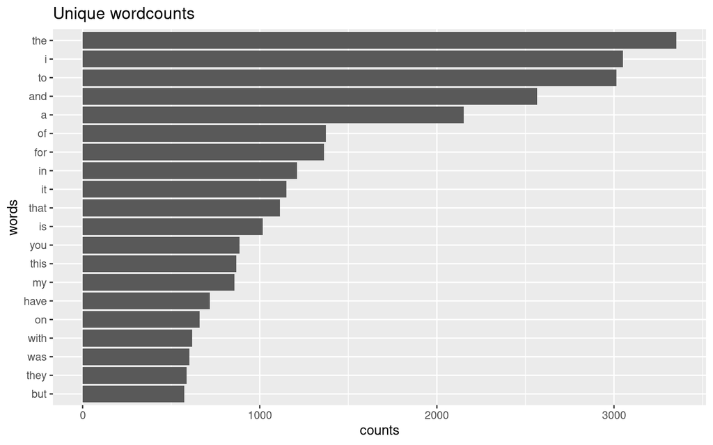

```r
# Tokenization (word tokens)
words <- threads_2 %>%
  unnest_tokens(output = word, input = text, token = "words")

words %>%
  count(word, sort = TRUE) %>%
  top_n(20) %>%
  mutate(word = reorder(word, n)) %>%
  ggplot(aes(x = word, y = n)) +
  geom_col() +
  xlab(NULL) +
  coord_flip() +
  labs(x = "words",
       y = "counts",
       title = "Unique wordcounts")
```

## 2-2: Stop words

Those words are so-called **stop words** – words that are commonly filtered out in the process of NLP because they are considered to be of little value in text analysis. These are typically common words that do not carry significant meaning on their own, such as articles, pronouns, conjunctions, and prepositions.

We will remove the stop words using a common stop words data set provided by `tidytext` package.

```r
# load list of stop words - from the tidytext package
data("stop_words")
# view random 50 words
print(stop_words$word[sample(1:nrow(stop_words), 50)])
```

```
##  [1] "he"           "alone"        "something"    "they'd"       "greatest"
##  [6] "even"         "think"        "still"        "those"        "otherwise"
## [11] "particularly" "are"          "however"      "who"          "case"
## [16] "will"         "show"         "help"         "only"         "different"
## [21] "me"           "specifying"   "anyway"       "serious"      "here"
## [26] "again"        "things"       "sorry"        "further"      "definitely"
## [31] "ours"         "ltd"          "whether"      "man"          "own"
## [36] "three"        "did"          "there's"      "knows"        "very"
## [41] "anyone"       "former"       "shouldn't"    "another"      "through"
## [46] "themselves"   "from"         "far"          "oldest"       "was"
```

We can use **anti_join()** function for the filtration. This function is part of the dplyr package. It removes stop words from the tweet text and saved as cleaned tweet words. This function works the same way as other *join* functions in that the **order of data.frame in the function argument matters.** Consider the schematic below: anti_join(A,B) will give you *everything from List A* except those that are also in List B. If you do anti_join(B,A), it will give you *everything in List B* except those that are in List A.

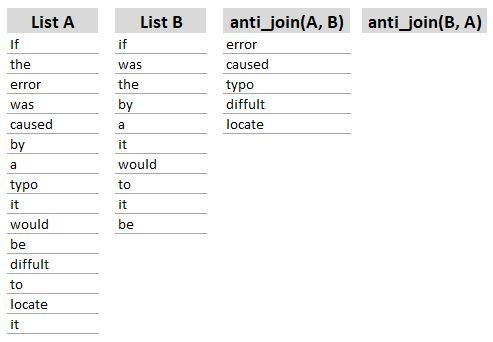

```r
# Regex that matches URL-type string
replace_reg <- "http[s]?://[A-Za-z\\d/\\.]+|&amp;|&lt;|&gt;"

words_clean <- threads_2 %>%
  # drop URLs
  mutate(text = str_replace_all(text, replace_reg, "")) %>%
  # Tokenization (word tokens)
  unnest_tokens(word, text, token = "words") %>%
  # drop stop words
  anti_join(stop_words, by = "word") %>%
  # drop non-alphabet-only strings
  filter(str_detect(word, "[a-z]"))

# Check the number of rows after removal of the stop words. There should be fewer words now
print(
  glue::glue("Before: {nrow(words)}, After: {nrow(words_clean)}")
)
```

```
## Before: 94378, After: 31160
```

Let’s create the plot using the cleaned version.

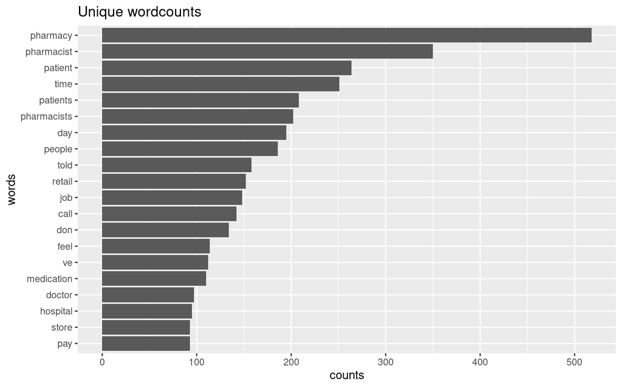

```r
words_clean %>%
  count(word, sort = TRUE) %>%
  top_n(20, n) %>%
  mutate(word = reorder(word, n)) %>%
  ggplot(aes(x = word, y = n)) +
  geom_col() +
  xlab(NULL) +
  coord_flip() +
  labs(x = "words",
       y = "counts",
       title = "Unique wordcounts")
```

# 3. Word cloud

Let’s compare the frequency of words before and after removing the stop words using word cloud.

```r
words %>%
  count(word, sort = TRUE) %>%
  wordcloud2()
```

[interactive chart not shown]

```r
words_clean %>%
  count(word, sort = TRUE) %>%
  wordcloud2()
```

[interactive chart not shown]

The word clouds above are nice, but the color scheme seems somewhat excessive.

This block of code generates a color palette designed to highlight a selected number of words while graying out the remaining ones. Creating a collection of random colors can be easily done by utilizing the HSV (Hue, Saturation, Value) color model.

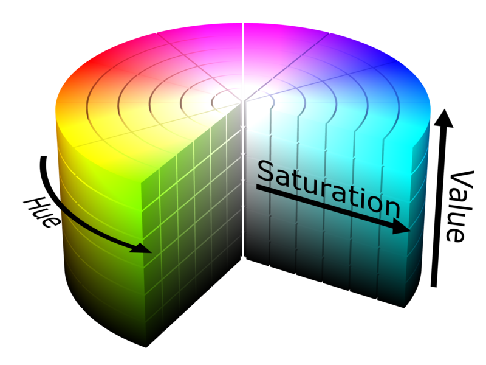

```r
n <- 20
h <- runif(n, 0, 1) # any color
s <- runif(n, 0.6, 1) # vivid
v <- runif(n, 0.3, 0.7) # neither too dark or bright

df_hsv <- data.frame(h = h, s = s, v = v)
pal <- apply(df_hsv, 1, function(x) hsv(x['h'], x['s'], x['v']))
pal <- c(pal, rep("grey", 10000))
```

```r
words_clean %>%
  count(word, sort = TRUE) %>%
  wordcloud2(color = pal,
             minRotation = 0,
             maxRotation = 0,
             ellipticity = 0.8)
```

[interactive chart not shown]

# 4. N-grams

N-gram is the sequence of n-words appearing together. For example *‘basketball coach’*, *‘dinner time’* are two words occurring together they are called i-grams. Similarly, *‘the three musketeers’* is a tri-gram, and *‘she was very hungry’* is a 4-gram. We will learn how to extract n-grams form the the Reddit text data, which will give further insights into the Reddit corpus. For advanced text analysis and machine learning based labeling, specific tokens, and n-grams can be used for feature engineering of the text data.

N-grams are used to analyze words in context. When we say (1) “We need to check the details.” and (2) “Can we pay it with a check?”, the word check are used as a verb and as a noun. We know what ‘check’ means in a sentence based on other words in the sentence, particularly words that are before and after the word ‘check.’ For example, if the word ‘check’ is used after ‘to’, we can infer that it is used as a verb. You can test bi-grams (2 words), tri-grams (3 words), and so on.

For example, “The result of separating bigrams is helpful for exploratory analyses of the text.” becomes **paired_words**  
1 the result  
2 result of  
3 of separating  
4 separating bigrams  
5 bigrams is  
6 is helpful  
7 helpful for  
8 for exploratory  
9 exploratory analyses  
10 analyses of  
11 of the  
12 the text

```r
#get ngrams. You may try playing around with the value of n, n=3 , n=4
words_ngram <- threads_2 %>%
  mutate(text = str_replace_all(text, replace_reg, "")) %>%
  select(text) %>%
  unnest_tokens(output = paired_words,
                input = text,
                token = "ngrams",
                n = 2)
```

```r
#show ngrams with sorted values
words_ngram %>%
  count(paired_words, sort = TRUE) %>%
  head(20) %>%
  knitr::kable()
```

| paired_words | n |
| --- | --- |
| i m | 279 |
| in the | 252 |
| NA | 244 |
| of the | 219 |
| and i | 210 |
| to the | 178 |
| i was | 163 |
| to be | 154 |
| i have | 152 |
| for the | 150 |
| for a | 145 |
| i am | 144 |
| it s | 143 |
| don t | 134 |
| so i | 110 |
| but i | 109 |
| to do | 106 |
| on the | 105 |
| as a | 104 |
| to get | 102 |

Here we see the ngrams are using stop words such as * a, to, etc.* Next we will try to obtain ngrams occurring without stop words. We will use the *separate* function of the *tidyr* library to obtain the paired words in two columns i.e. *word 1* and *word 2*. Subsequently we filter out columns containing stop words using the *filter fucntion*

```r
#separate the paired words into two columns
words_ngram_pair <- words_ngram %>%
  separate(paired_words, c("word1", "word2"), sep = " ")

# filter rows where there are stop words under word 1 column and word 2 column
words_ngram_pair_filtered <- words_ngram_pair %>%
  # drop stop words
  filter(!word1 %in% stop_words$word & !word2 %in% stop_words$word) %>%
  # drop non-alphabet-only strings
  filter(str_detect(word1, "[a-z]") & str_detect(word2, "[a-z]"))

# Filter out words that are not encoded in ASCII
# To see what's ASCCII, google 'ASCII table'
library(stringi)
words_ngram_pair_filtered %<>%
  filter(stri_enc_isascii(word1) & stri_enc_isascii(word2))

# Sort the new bi-gram (n=2) counts:
words_counts <- words_ngram_pair_filtered %>%
  count(word1, word2) %>%
  arrange(desc(n))

head(words_counts, 20) %>%
  knitr::kable()
```

| word1 | word2 | n |
| --- | --- | --- |
| retail | pharmacy | 29 |
| pharmacy | school | 20 |
| weight | loss | 17 |
| staff | pharmacist | 16 |
| pharmacy | manager | 15 |
| ms | mah | 13 |
| community | pharmacy | 12 |
| independent | pharmacy | 12 |
| grocery | store | 11 |
| pharmacy | staff | 11 |
| phone | calls | 11 |
| health | care | 10 |
| retail | pharmacist | 10 |
| store | manager | 10 |
| student | loans | 10 |
| clinical | pharmacist | 9 |
| doctor’s | office | 9 |
| hospital | pharmacist | 9 |
| insurance | company | 9 |
| pharmacy | tech | 9 |

By using the igraph and ggraph we can visualize the words occurring in pairs.

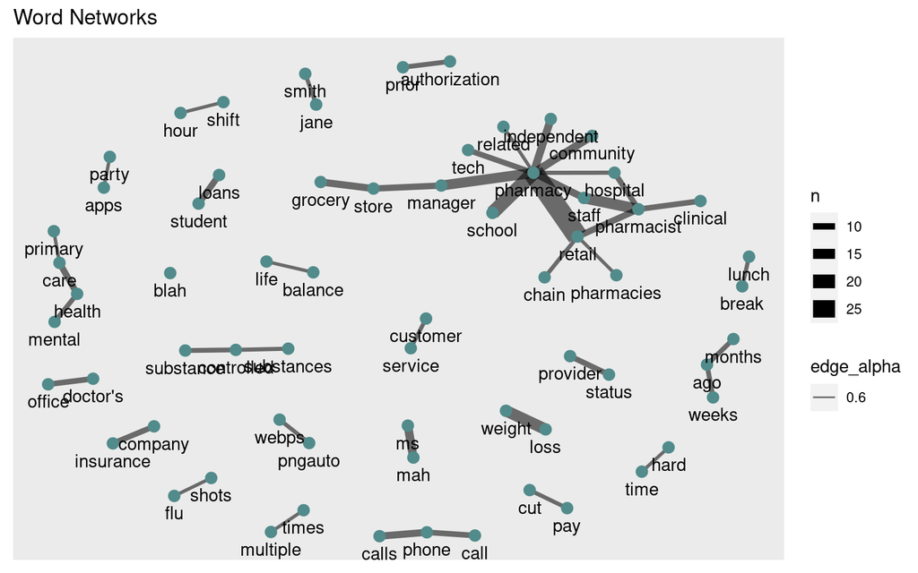

```r
# plot word network
words_counts %>%
  filter(n >= 6) %>%
  graph_from_data_frame() %>%
  ggraph(layout = "fr") +
  geom_edge_link(aes(edge_alpha = .6, edge_width = n)) +
  geom_node_point(color = "darkslategray4", size = 3) +
  geom_node_text(aes(label = name), vjust = 1.8) +
  labs(title = "Word Networks",
       x = "", y = "")
```